# Simulation

X. Li

Fall 2019

A powerful feature of `R` is its ability to perform simulations. In these notes we will use simulation to look at the Central Limit Theorem.

# Reproducability

When performing simulations, it can be helpful to obtain the same “random” results each time. For this reason, at the beginning of a `.R` script or R Markdown file, we will begin by setting a seed.

```r
set.seed(12345)
```

By doing this, if we perform operations in the same order, we will also obtain the same results each time. This may be helpful for answering question about simulations you ran. Here I used a seed of `12345`, but in homework, you should use your UIN.

# Probability Functions in `R`

Recall that `R` can easily calculate probabilities for various built in distributions using `d` and `p` functions. Here we also see examples of plotting discrete and continuous distributions.

```r
dbinom(3, 20, 0.2)
```

```
## [1] 0.2053641
```

```r
pbinom(3, 20, 0.2)
```

```
## [1] 0.4114489
```

```r
dbinom(0:20, 20, 0.2)
```

```
##  [1] 1.152922e-02 5.764608e-02 1.369094e-01 2.053641e-01 2.181994e-01
##  [6] 1.745595e-01 1.090997e-01 5.454985e-02 2.216088e-02 7.386959e-03
## [11] 2.031414e-03 4.616849e-04 8.656592e-05 1.331783e-05 1.664729e-06
## [16] 1.664729e-07 1.300570e-08 7.650410e-10 3.187671e-11 8.388608e-13
## [21] 1.048576e-14
```

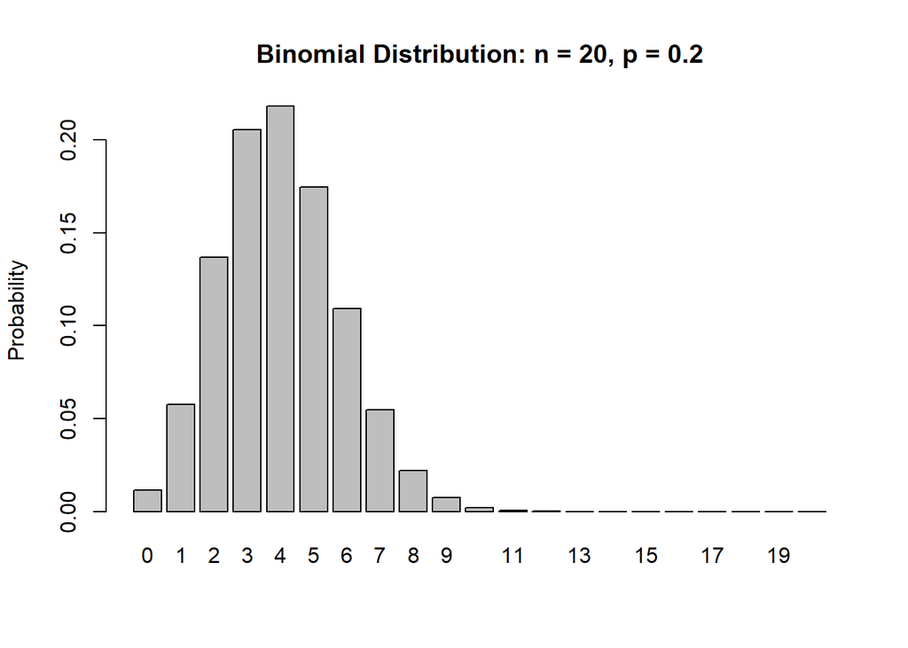

```r
barplot(
  dbinom(0:20, 20, 0.2),
  main = "Binomial Distribution: n = 20, p = 0.2",
  ylab = "Probability",
  names.arg = 0:20
)
```

```r
dnorm(2, 0, 1)
```

```
## [1] 0.05399097
```

```r
pnorm(2, 0, 1)
```

```
## [1] 0.9772499
```

```r
qnorm(0.025, 0, 1, lower.tail = FALSE)
```

```
## [1] 1.959964
```

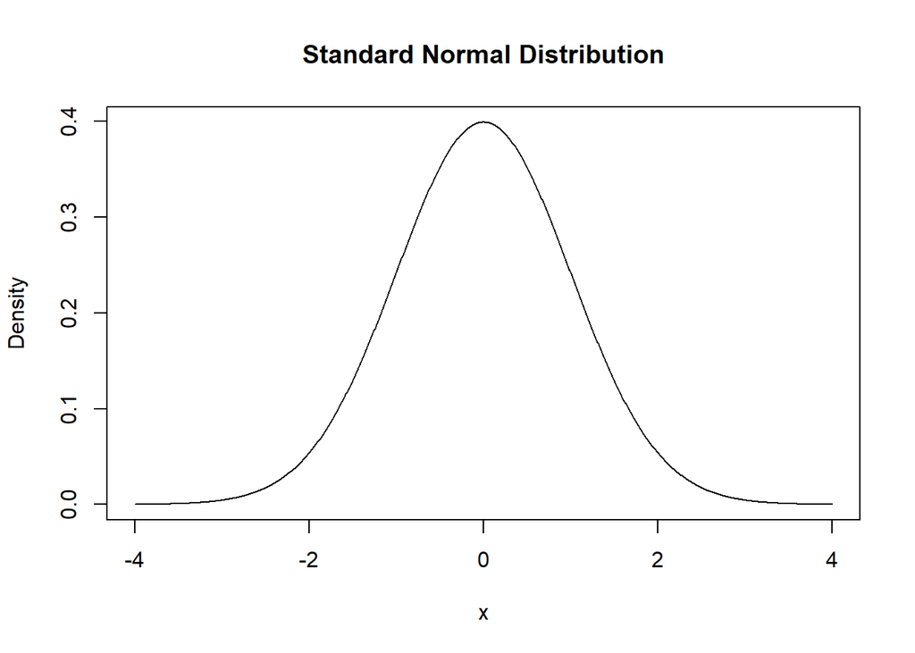

```r
x = seq(-4, 4, length = 1000)
plot(x, dnorm(x), type = "l", main = "Standard Normal Distribution", ylab = "Density")
```

In addition to functions for calculating probabilities, `R` also has functions for simulating from various distributions.

```r
rbinom(10, 20, 0.2)
```

```
##  [1] 5 6 5 6 4 2 3 4 5 8
```

```r
rnorm(10, 0, 1)
```

```
##  [1] -1.8179560  0.6300986 -0.2761841 -0.2841597 -0.9193220 -0.1162478
##  [7]  1.8173120  0.3706279  0.5202165 -0.7505320
```

```r
sample(1:100, 10, replace = FALSE)
```

```
##  [1] 80  1 19 67 36 35 82 85 57 13
```

Here we first obtained $10$ observations from a binomial distribution with $n = 20$ and $p = 0.2$ then $10$ observations from a normal distribution with $\mu = 0$ and $\sigma = 1$. The last command obtains a sample of size $10$ from the numbers $1$ to $100$, without replacement.

# Central Limit Theorem

If the sample size, $n$, if large, then the sampling distribution of the sample mean, $\bar{x}$ is approximately **normal** with mean $\mu$ and standard deviation $\sigma / \sqrt{n}$. Thus,
$$\frac{\bar{x} - \mu}{\sigma / \sqrt{n}} \sim N(0, 1)$$

Also, recall if the population distribution is normal, then the result is exact, not approximate. And if the population is not normal, but the sample size is “small,” we’re out of luck and the CLT does not apply.

Here we will take $1000$ samples of size $100$ from a $t$ distribution with $10$ degrees of freedom. We then calculate $\bar{x}$ for each at plot a histogram and QQ plot.

```r
num_sim = 1000
n = 100

x_bars = rep(0, num_sim)
for (i in 1:num_sim) {
  samp = rt(n, 10)
  x_bars[i] = mean(samp)
}

c(mean(x_bars), sd(x_bars))
```

```
## [1] 0.001492439 0.113730222
```

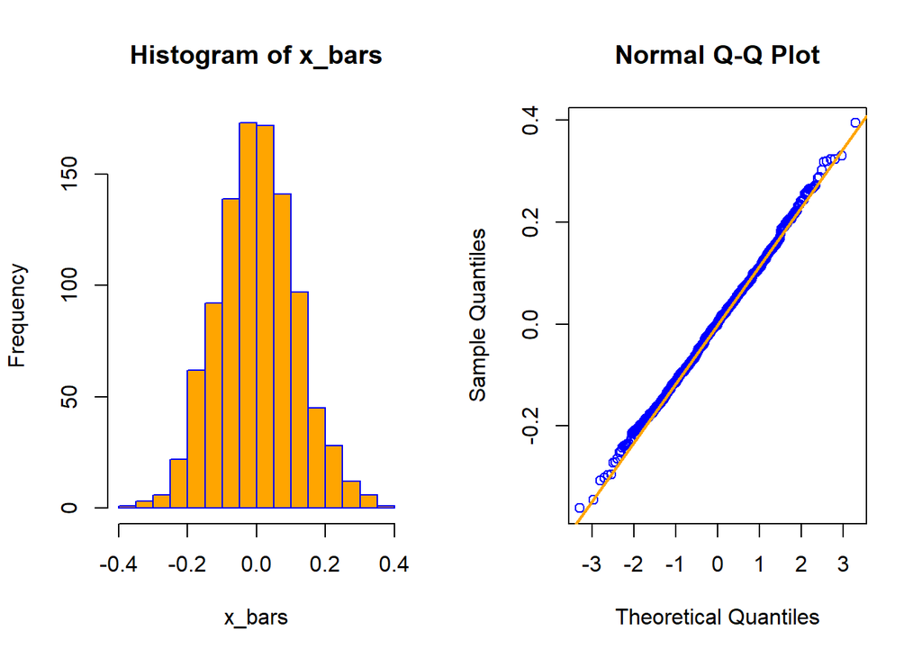

```r
par(mfrow = c(1, 2))
hist(x_bars, breaks = 12, col = "orange", border = "blue")
qqnorm(x_bars, col = "blue")
qqline(x_bars, col = "orange", lwd = 2)
```

The QQ plot looks to be normal, so $100$ is a large enough sample size for the CLT to apply.

The following code, repeats the process above, but in a more `R` way, this time simulating from a Poisson distribution with $\lambda = 0.6$. This time we take $1000$ samples of size $5$.

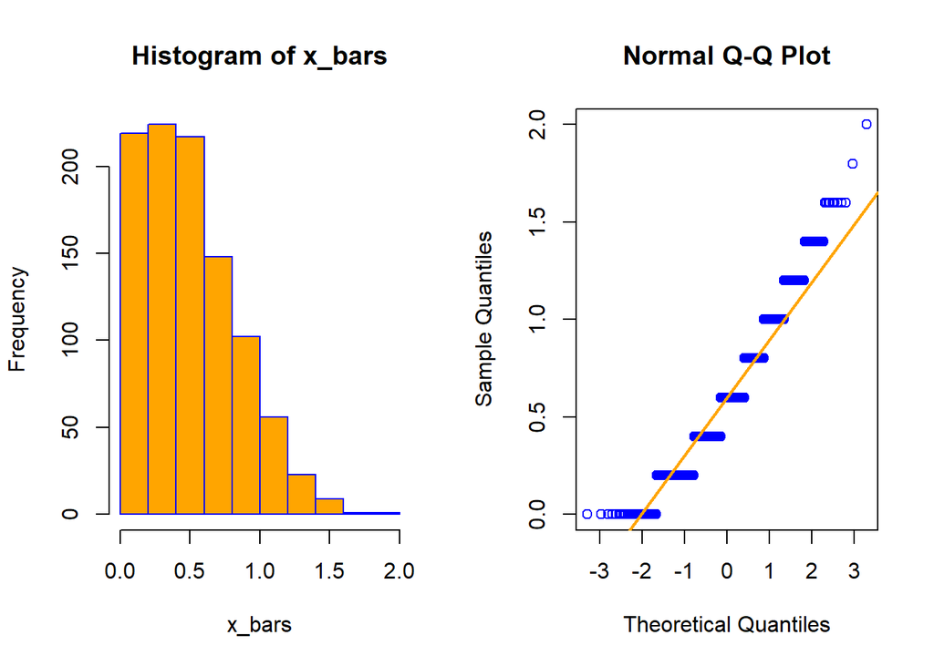

```r
samples = replicate(1000, rpois(5, 0.6))
x_bars = apply(samples, 2, mean)
par(mfrow = c(1, 2))
hist(x_bars, breaks = 12, col = "orange", border = "blue")
qqnorm(x_bars, col = "blue")
qqline(x_bars, col = "orange", lwd = 2)
```

This time the results do not appear to be normal. $5$ is not a large enough sample size for the CLT to apply.